# **Assignment 6**

#### **Topic: Predicting diabetes using Classification Trees, SVM, and Logistic Regression**

The posted article by Yu et al utilized NHANES data from 1999-2004 to predict diabetes and pre-diabetes using Support Vector Machines. You will conduct a similar analysis using data within the NHANES package in R.

**Goal:** To predict diabetes status using behavioral, demographic, and clinical features, and to conduct a reproducible analysis to build and compare three classification models: a classification tree, a support vector classifier (linear kernel), and logistic regression.

**Feature Information:** There are 10 features and one outcome variable within the dataset.

- `Diabetes`: Yes, No (Outcome) [Categorical]
- `Age`: Age in years [Continuous]
- `Race1`: Self-reported race/ethnicity [Categorical]
- `Education`: Highest level of education completed [Categorical]
- `HHIncome`: Household income category [Categorical]
- `Weight`: Weight in kilograms [Continuous]
- `Height`: Height in centimeters [Continuous]
- `Pulse`: Resting pulse rate (beats per minute) [Continuous]
- `BMI`: Body Mass Index [Continuous]
- `PhysActive`: Physically active (Yes/No) [Categorical]
- `Smoke100`: Smoked at least 100 cigarettes lifetime (Yes/No) [Categorical]

#### **0. Data Preparation**

Load the NHANES data using the NHANES R package.

**Set up needed libraries**

```r
library(NHANES)
library(tidyverse)
library(caret)
library(rpart)
library(rpart.plot)
library(e1071)
library(kernlab)
library(pROC)

set.seed(123)
```

**Load and restrict dataset**

Restrict the NHANES data to the list of **11 variables** (“Age”, “Race1”, “Education”, “HHIncome”, “Weight”, “Height”, “Pulse”, “Diabetes”, “BMI”, “PhysActive”, “Smoke100”).

```r
vars.keep = c("Age", "Race1", "Education", "HHIncome", "Weight",
               "Height", "Pulse", "Diabetes", "BMI", "PhysActive", "Smoke100")

nhanes.df = NHANES |>
  select(all_of(vars.keep)) |>
  distinct() |>       # remove oversampled duplicate rows
  drop_na()

nhanes.df
```

```
## # A tibble: 4,040 × 11
##      Age Race1  Education HHIncome Weight Height Pulse Diabetes   BMI PhysActive
##    <int> <fct>  <fct>     <fct>     <dbl>  <dbl> <int> <fct>    <dbl> <fct>
##  1    34 White  High Sch… 25000-3…   87.4   165.    70 No        32.2 No
##  2    49 White  Some Col… 35000-4…   86.7   168.    86 No        30.6 No
##  3    45 White  College … 75000-9…   75.7   167.    62 No        27.2 Yes
##  4    66 White  Some Col… 25000-3…   68     170.    60 No        23.7 Yes
##  5    58 White  College … more 99…   78.4   182.    62 No        23.7 Yes
##  6    54 White  9 - 11th… 65000-7…   74.7   169.    76 No        26.0 Yes
##  7    58 Mexic… High Sch… 75000-9…   57.5   148.    94 No        26.2 Yes
##  8    50 White  Some Col… 15000-1…   84.1   178.    74 No        26.6 Yes
##  9    33 White  High Sch… 25000-3…   93.8   181.    96 No        28.5 No
## 10    60 White  High Sch… 15000-1…   74.6   170.    84 No        25.8 No
## # ℹ 4,030 more rows
## # ℹ 1 more variable: Smoke100 <fct>
```

**Clean dataset**

```r
# Set reference levels for binary variables and confirm factor types for all categorical variables
nhanes.df = nhanes.df |>
  mutate(
    Diabetes   = factor(Diabetes,   levels = c("No", "Yes")),
    PhysActive = factor(PhysActive, levels = c("No", "Yes")),
    Smoke100   = factor(Smoke100,   levels = c("No", "Yes")),
    Race1      = as.factor(Race1),
    Education  = as.factor(Education),
    HHIncome   = as.factor(HHIncome)
  )

nhanes.df
```

```
## # A tibble: 4,040 × 11
##      Age Race1  Education HHIncome Weight Height Pulse Diabetes   BMI PhysActive
##    <int> <fct>  <fct>     <fct>     <dbl>  <dbl> <int> <fct>    <dbl> <fct>
##  1    34 White  High Sch… 25000-3…   87.4   165.    70 No        32.2 No
##  2    49 White  Some Col… 35000-4…   86.7   168.    86 No        30.6 No
##  3    45 White  College … 75000-9…   75.7   167.    62 No        27.2 Yes
##  4    66 White  Some Col… 25000-3…   68     170.    60 No        23.7 Yes
##  5    58 White  College … more 99…   78.4   182.    62 No        23.7 Yes
##  6    54 White  9 - 11th… 65000-7…   74.7   169.    76 No        26.0 Yes
##  7    58 Mexic… High Sch… 75000-9…   57.5   148.    94 No        26.2 Yes
##  8    50 White  Some Col… 15000-1…   84.1   178.    74 No        26.6 Yes
##  9    33 White  High Sch… 25000-3…   93.8   181.    96 No        28.5 No
## 10    60 White  High Sch… 15000-1…   74.6   170.    84 No        25.8 No
## # ℹ 4,030 more rows
## # ℹ 1 more variable: Smoke100 <fct>
```

**Overview of continuous features**

```r
nhanes.df |>
  summarise(across(where(is.numeric),
                   list(Mean = ~round(mean(.), 2),
                        SD   = ~round(sd(.), 2),
                        Min  = ~round(min(.), 2),
                        Max  = ~round(max(.), 2)))) |>
  pivot_longer(everything(),
               names_to  = c("Variable", "Stat"),
               names_sep = "_(?=[^_]+$)") |>
  pivot_wider(names_from  = Stat,
              values_from = value) |>
  knitr::kable(caption = "Table 1: Descriptive Statistics of Continuous Features")
```

Table 1: Descriptive Statistics of Continuous Features

| Variable | Mean | SD | Min | Max |
| --- | --- | --- | --- | --- |
| Age | 47.40 | 17.36 | 20.00 | 80.00 |
| Weight | 82.69 | 21.41 | 37.00 | 230.70 |
| Height | 168.62 | 10.10 | 139.90 | 200.40 |
| Pulse | 72.43 | 11.86 | 40.00 | 128.00 |
| BMI | 29.02 | 6.89 | 15.02 | 81.25 |

**Check outcome balance**

```r
balance.tbl = nhanes.df |>
  count(Diabetes) |>
  mutate(Percent = round(100 * n / sum(n), 1))

balance.tbl |>
  knitr::kable(caption = "Table 2: Frequency and Proportion of Diabetes Outcome")
```

Table 2: Frequency and Proportion of Diabetes Outcome

| Diabetes | n | Percent |
| --- | --- | --- |
| No | 3562 | 88.2 |
| Yes | 478 | 11.8 |

**NOTE:** From **Table 2**, we see an imbalance in the outcome variable, with 88.2% of participants classified as non-diabetic and 11.8% as diabetic. To address this, down-sampling will be applied during cross-validation to prevent models from being biased toward the majority class.

**Partition the data into training and testing using a 70/30 split**

```r
set.seed(123)

train.indices = createDataPartition(y = nhanes.df$Diabetes, p = 0.7, list = FALSE)
train.data    = nhanes.df[ train.indices, ]
test.data     = nhanes.df[-train.indices, ]

split.counts = tibble(
  Dataset = c("Training data", "Testing data"),
  N       = c(nrow(train.data), nrow(test.data)),
  Percent = round(100 * N / nrow(nhanes.df), 1)
)

split.counts |>
  knitr::kable(caption = "Table 3: Number of Observations in Training and Test Sets")
```

Table 3: Number of Observations in Training and Test Sets

| Dataset | N | Percent |
| --- | --- | --- |
| Training data | 2829 | 70 |
| Testing data | 1211 | 30 |

**NOTE:** After reviewing the data structure, descriptive statistics, and outcome balance, all 10 features are retained for modeling. No features are excluded based on the following reasoning:

- `Age` and `BMI` are well-established clinical risk factors for diabetes
- `Weight` and `Height` capture body composition information that may complement BMI
- `PhysActive` and `Smoke100` are known behavioral risk factors
- `Race1`, `Education`, and `HHIncome` reflect socioeconomic and demographic context associated with structural health disparities in diabetes risk.
- `Pulse` is retained as a physiological measure linked to cardiovascular health, which is closely associated with diabetes.

Lastly, after removing duplicate rows introduced by the NHANES survey oversampling design and retain only complete cases (no missing data), 4,040 observations remained which is sufficient sample size to support all three modeling approaches.

#### **1. The Comparison of Three Models**

Construct **three prediction models** to predict diabetes using the features from NHANES. You will optimize each model using cross-validation to choose hyperparameters in the *training data* and then compare performance across models. You will use the following three algorithms to create your prediction models:

First, a shared 10-fold cross-validation control is created to use across all three models. *Down-sampling* is applied within each fold to correct for the class imbalance in the outcome.

```r
train.control = trainControl(
  method          = "cv",
  number          = 10,
  sampling        = "down",
  classProbs      = TRUE,    #allow probability predictions needed for ROC evaluation
  savePredictions = "final"
)
```

**a) Classification Tree**

A classification tree that tunes the complexity parameter (`cp`) via 10-fold cross-validation.

```r
set.seed(123)

grid.tree = expand.grid(cp = seq(0.001, 0.3, by = 0.01))

model.tree = train(
  Diabetes ~ .,
  data      = train.data,
  method    = "rpart",
  trControl = train.control,
  tuneGrid  = grid.tree
)

# Best cp
model.tree$bestTune
```

```
##      cp
## 1 0.001
```

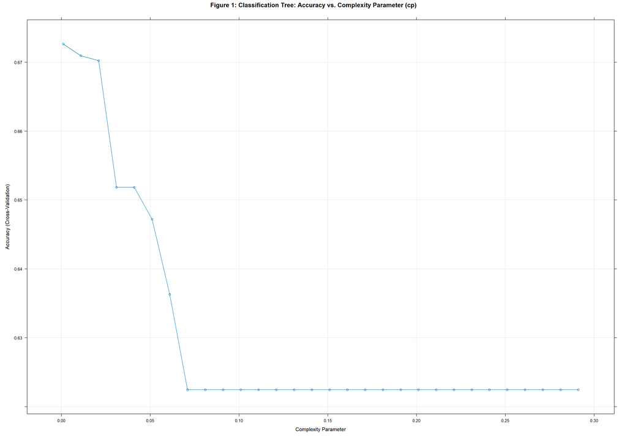

```r
# CV performance across cp values
plot(model.tree, uniform = TRUE,
     main = "Figure 1: Classification Tree: Accuracy vs. Complexity Parameter (cp)")
```

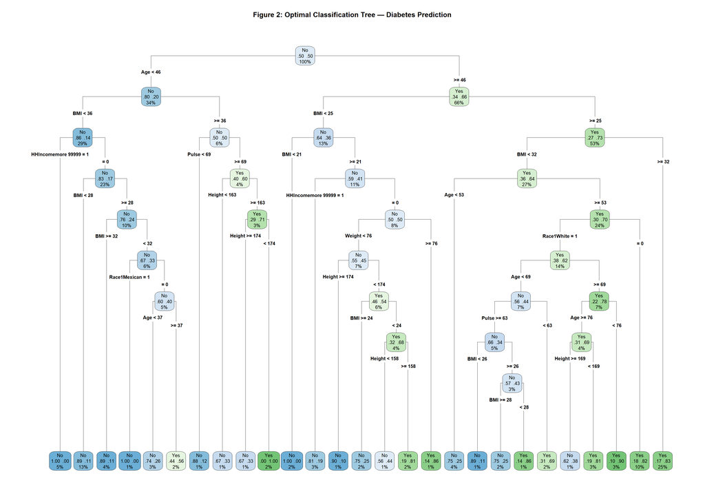

```r
# Visualize the final tree
model.tree$finalModel |>
  rpart.plot(type = 4, extra = 104,
             main = "Figure 2: Optimal Classification Tree — Diabetes Prediction")
```

```r
# Variable importance
varImp(model.tree)
```

```
## rpart variable importance
##
##   only 20 most important variables shown (out of 35)
##
##                         Overall
## Age                     100.000
## BMI                      89.936
## Weight                   53.262
## PhysActiveYes            29.921
## Height                   26.160
## Pulse                    24.373
## EducationCollege Grad    23.467
## HHIncomemore 99999       17.664
## Race1White               13.174
## HHIncome75000-99999       6.656
## Education9 - 11th Grade   5.380
## EducationHigh School      4.971
## HHIncome45000-54999       3.210
## HHIncome 5000-9999        2.975
## Smoke100Yes               2.426
## Race1Mexican              2.062
## EducationSome College     1.905
## HHIncome25000-34999       1.145
## `EducationSome College`   0.000
## Race1Hispanic             0.000
```

```r
# Cross-validated confusion matrix from training
confusionMatrix(model.tree)
```

```
## Cross-Validated (10 fold) Confusion Matrix
##
## (entries are percentual average cell counts across resamples)
##
##           Reference
## Prediction   No  Yes
##        No  59.2  3.8
##        Yes 29.0  8.1
##
##  Accuracy (average) : 0.6727
```

**b) Support Vector Classifier (i.e. Support Vector Machine with a linear classifier)**

```r
set.seed(123)

model.svm = train(
  Diabetes ~ .,
  data       = train.data,
  method     = "svmLinear",
  trControl  = train.control,
  preProcess = c("center", "scale"),
  tuneGrid   = expand.grid(C = seq(0.001, 2, length = 30))
)

# Best cost parameter
model.svm$bestTune
```

```
##           C
## 21 1.379621
```

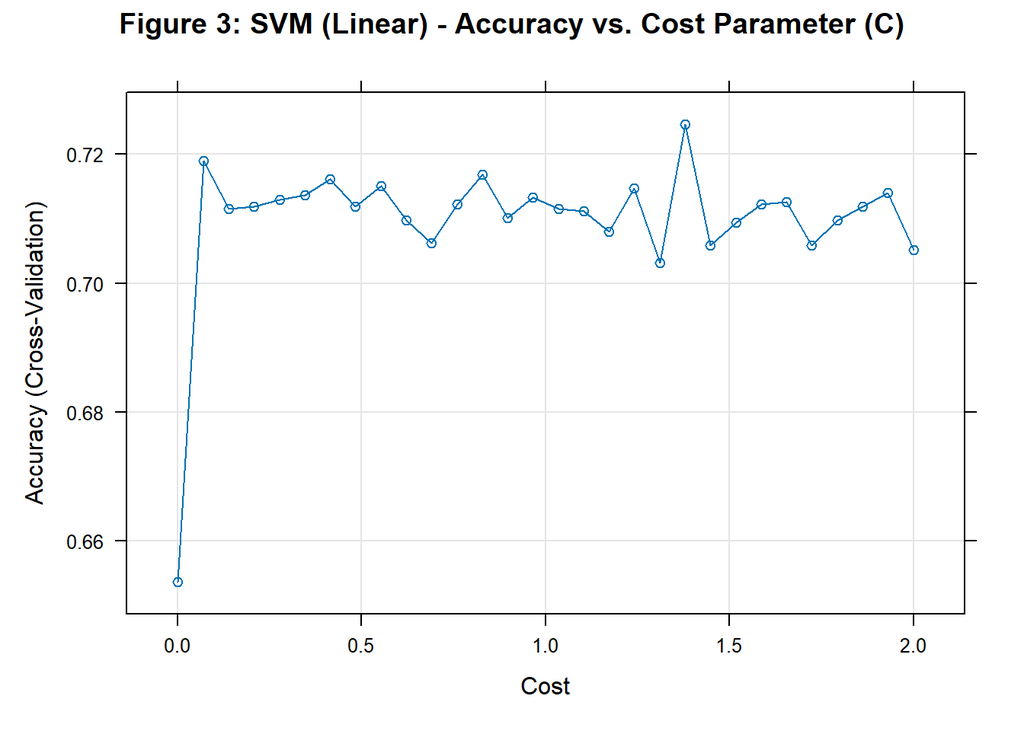

```r
# Plot accuracy vs. cost
plot(model.svm,
     main = "Figure 3: SVM (Linear) - Accuracy vs. Cost Parameter (C)")
```

```r
# Cross-validated confusion matrix from training
confusionMatrix(model.svm)
```

```
## Cross-Validated (10 fold) Confusion Matrix
##
## (entries are percentual average cell counts across resamples)
##
##           Reference
## Prediction   No  Yes
##        No  63.3  2.7
##        Yes 24.8  9.2
##
##  Accuracy (average) : 0.7246
```

```r
# NOTE: varImp() is not computed for svmLinear with down-sampling
# as caret's ROC-based importance is incompatible with this configuration
```

**Description:** The cost parameter C was optimally set to 1.38 via cross-validation, yielding a mean CV accuracy of 72.5% after down-sampling. As shown in *Figure 3*, accuracy is lowest at very small C values (~65.5%) but stabilizes at 71–72% for moderate to large values, indicating the model is robust to the choice of C above a certain threshold. The cross-validated confusion matrix shows the model correctly identified 9.2% of true diabetic cases and 63.3% of non-diabetic cases on average across folds.

**c) Logistic Regression**

A base logistic regression model using all features, evaluated via 10-fold cross-validation.

```r
set.seed(123)

model.logistic = train(
  Diabetes ~ .,
  data       = train.data,
  method     = "glm",
  family     = "binomial",
  trControl  = train.control,
  preProcess = c("center", "scale")
)

# Coefficient summary
summary(model.logistic$finalModel)
```

```
##
## Call:
## NULL
##
## Coefficients:
##                           Estimate Std. Error z value Pr(>|z|)
## (Intercept)               -0.02739    0.09638  -0.284   0.7762
## Age                        1.26157    0.12139  10.393   <2e-16 ***
## Race1Hispanic              0.11100    0.11268   0.985   0.3246
## Race1Mexican               0.10613    0.12375   0.858   0.3911
## Race1White                -0.17188    0.13230  -1.299   0.1939
## Race1Other                 0.24148    0.11698   2.064   0.0390 *
## `Education9 - 11th Grade`  0.05679    0.15173   0.374   0.7082
## `EducationHigh School`    -0.11417    0.16408  -0.696   0.4865
## `EducationSome College`    0.11293    0.18868   0.598   0.5495
## `EducationCollege Grad`   -0.18673    0.19483  -0.958   0.3379
## `HHIncome 5000-9999`       0.15003    0.15071   0.995   0.3195
## `HHIncome10000-14999`     -0.07705    0.18868  -0.408   0.6830
## `HHIncome15000-19999`     -0.11848    0.19001  -0.624   0.5329
## `HHIncome20000-24999`     -0.15820    0.20632  -0.767   0.4432
## `HHIncome25000-34999`      0.03163    0.21482   0.147   0.8829
## `HHIncome35000-44999`     -0.01517    0.22001  -0.069   0.9450
## `HHIncome45000-54999`      0.02897    0.19775   0.147   0.8835
## `HHIncome55000-64999`     -0.09471    0.17618  -0.538   0.5909
## `HHIncome65000-74999`     -0.12700    0.18010  -0.705   0.4807
## `HHIncome75000-99999`     -0.17836    0.21138  -0.844   0.3988
## `HHIncomemore 99999`      -0.22341    0.25843  -0.865   0.3873
## Weight                    -0.58438    1.00136  -0.584   0.5595
## Height                     0.32819    0.43909   0.747   0.4548
## Pulse                      0.16776    0.10023   1.674   0.0942 .
## BMI                        1.43922    0.94163   1.528   0.1264
## PhysActiveYes             -0.08747    0.10359  -0.844   0.3985
## Smoke100Yes                0.08989    0.10109   0.889   0.3739
## ---
## Signif. codes:  0 '***' 0.001 '**' 0.01 '*' 0.05 '.' 0.1 ' ' 1
##
## (Dispersion parameter for binomial family taken to be 1)
##
##     Null deviance: 928.82  on 669  degrees of freedom
## Residual deviance: 666.35  on 643  degrees of freedom
## AIC: 720.35
##
## Number of Fisher Scoring iterations: 5
```

```r
# Cross-validated performance
model.logistic$results
```

```
##   parameter  Accuracy     Kappa AccuracySD    KappaSD
## 1      none 0.7186289 0.2586378 0.03169238 0.04918597
```

```r
# Variable importance
varImp(model.logistic)
```

```
## glm variable importance
##
##   only 20 most important variables shown (out of 26)
##
##                         Overall
## Age                     100.000
## Race1Other               19.326
## Pulse                    15.545
## BMI                      14.137
## Race1White               11.917
## `HHIncome 5000-9999`      8.975
## Race1Hispanic             8.874
## `EducationCollege Grad`   8.615
## Smoke100Yes               7.945
## `HHIncomemore 99999`      7.706
## Race1Mexican              7.639
## PhysActiveYes             7.511
## `HHIncome75000-99999`     7.505
## `HHIncome20000-24999`     6.759
## Height                    6.572
## `HHIncome65000-74999`     6.163
## `EducationHigh School`    6.072
## `HHIncome15000-19999`     5.372
## `EducationSome College`   5.129
## Weight                    4.985
```

```r
# Cross-validated confusion matrix from training
confusionMatrix(model.logistic)
```

```
## Cross-Validated (10 fold) Confusion Matrix
##
## (entries are percentual average cell counts across resamples)
##
##           Reference
## Prediction   No  Yes
##        No  63.0  2.9
##        Yes 25.2  8.9
##
##  Accuracy (average) : 0.7186
```

#### **2. Model Selection**

Select an “optimal” model and calculate final evaluation metrics in the test set. ONLY ONE MODEL SHOULD BE APPLIED IN THE TEST SET. What do you conclude about your final model’s performance?

**Compare Models on Training Performance**

```r
results = resamples(list(
  ClassTree = model.tree,
  SVM       = model.svm,
  Logistic  = model.logistic
))

summary(results)
```

```
##
## Call:
## summary.resamples(object = results)
##
## Models: ClassTree, SVM, Logistic
## Number of resamples: 10
##
## Accuracy
##                Min.   1st Qu.    Median      Mean   3rd Qu.      Max. NA's
## ClassTree 0.6028369 0.6651943 0.6701899 0.6726446 0.6817376 0.7420495    0
## SVM       0.6607774 0.7084806 0.7359155 0.7246597 0.7409343 0.7659574    0
## Logistic  0.6784452 0.6932029 0.7125180 0.7186289 0.7491135 0.7632509    0
##
## Kappa
##                Min.   1st Qu.    Median      Mean   3rd Qu.      Max. NA's
## ClassTree 0.1195852 0.1409487 0.1730438 0.1848086 0.2087926 0.3221446    0
## SVM       0.1727666 0.2417549 0.2749648 0.2725940 0.3148994 0.3523068    0
## Logistic  0.1851165 0.2278609 0.2638915 0.2586378 0.2989948 0.3228456    0
```

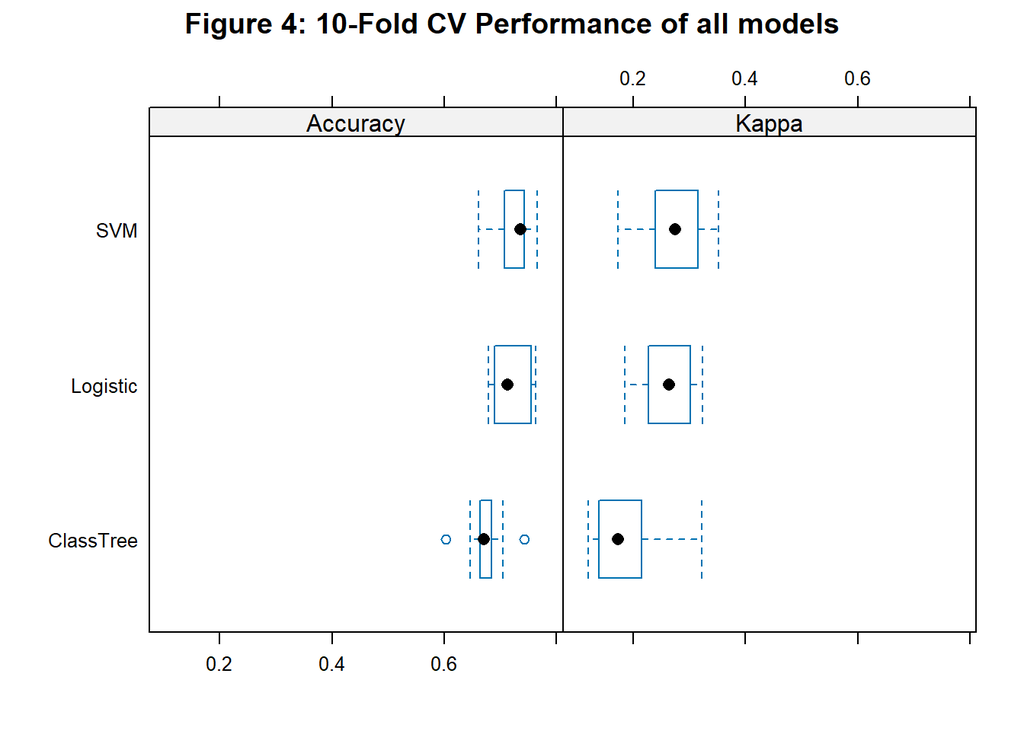

```r
bwplot(results,
       main = "Figure 4: 10-Fold CV Performance of all models")
```

**Description:** As shown in *accuracy and Kappa results* above and *Figure 4*, SVM achieved the highest mean CV accuracy (72.47%) and Kappa (0.273), followed by logistic regression (71.86%, Kappa = 0.259), while the classification tree performed notably worse (67.26%, Kappa = 0.185). Despite SVM’s marginally higher performance, **logistic regression is selected as the final model** because it offers comparable predictive performance while providing interpretable coefficients. This is an important consideration in a health research context where understanding the direction and magnitude of predictor effects can inform clinical decision-making.

**Final Model Evaluation (Test Set)**

The final logistic regression model is applied once to the held-out test set to report unbiased evaluation metrics.

```r
set.seed(123)

final.pred = predict(model.logistic, newdata = test.data)

confusionMatrix(final.pred, test.data$Diabetes, positive = "Yes")
```

```
## Confusion Matrix and Statistics
##
##           Reference
## Prediction  No Yes
##        No  756  31
##        Yes 312 112
##
##                Accuracy : 0.7168
##                  95% CI : (0.6905, 0.742)
##     No Information Rate : 0.8819
##     P-Value [Acc > NIR] : 1
##
##                   Kappa : 0.2653
##
##  Mcnemar's Test P-Value : <2e-16
##
##             Sensitivity : 0.78322
##             Specificity : 0.70787
##          Pos Pred Value : 0.26415
##          Neg Pred Value : 0.96061
##              Prevalence : 0.11808
##          Detection Rate : 0.09249
##    Detection Prevalence : 0.35012
##       Balanced Accuracy : 0.74554
##
##        'Positive' Class : Yes
##
```

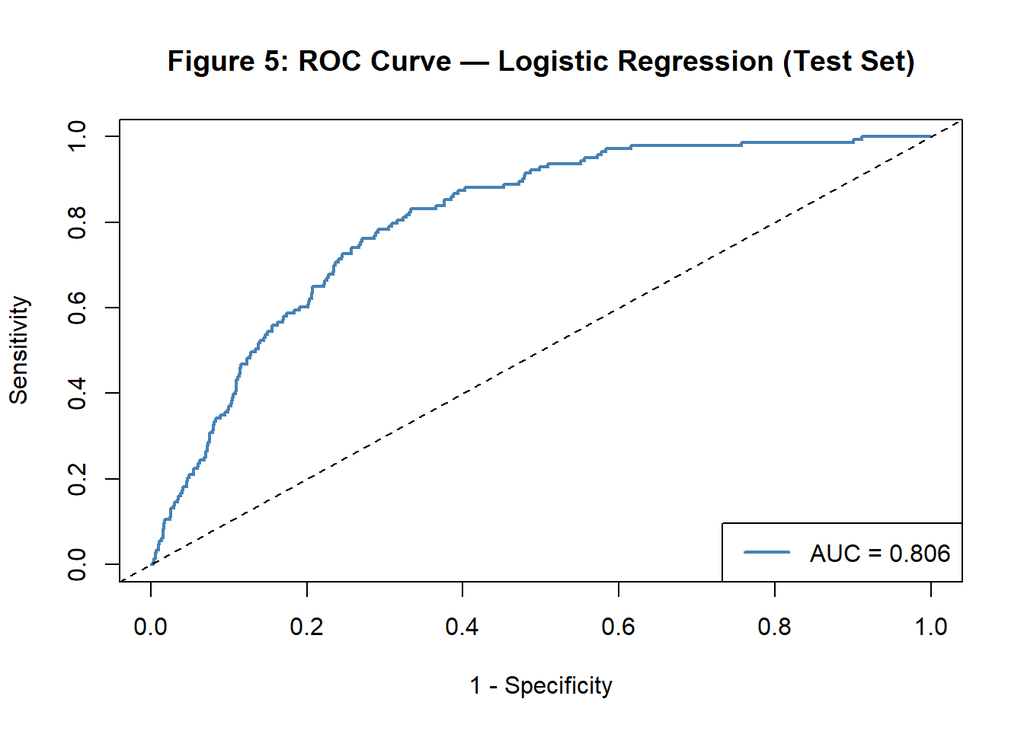

```r
final.pred.prob = predict(model.logistic, newdata = test.data, type = "prob")

roc.analysis = roc(
  response  = test.data$Diabetes,
  predictor = final.pred.prob[, "Yes"]
)

plot(
  1 - roc.analysis$specificities,
  roc.analysis$sensitivities,
  type = "l", col = "steelblue", lwd = 2,
  ylab = "Sensitivity",
  xlab = "1 - Specificity",
  main = "Figure 5: ROC Curve — Logistic Regression (Test Set)"
)
abline(a = 0, b = 1, lty = 2)
legend("bottomright",
       legend = paste("AUC =", round(auc(roc.analysis), 3)),
       col = "steelblue", lwd = 2)
```

```r
cat("Test Set AUC:", round(auc(roc.analysis), 3), "\n")
```

```
## Test Set AUC: 0.806
```

**Description:** In the test set, the logistic regression model achieved an accuracy of 71.68% and a Kappa of 0.2653. The model correctly identified 78.32% of true diabetic cases (sensitivity) and correctly classifying 70.79% of non-diabetic individuals (specificity). In addition, the AUC of 0.806 confirms good overall performance of the model, substantially above the 0.5 baseline of random guessing. Overall, the model demonstrates good discriminative ability for identifying diabetic individuals in a population setting, though the low PPV (26.4%) suggests it is better suited as a screening tool than a diagnostic one.

#### **3. Ethical Considerations of Including Race in a Disease Prediction Model**

In this analysis, we’ve used `Race` as one of the predictors in the model. Briefly discuss the ethical considerations of including race in a disease prediction model.

**Answer:** Including `Race1` as a predictor in a diabetes prediction model raises important ethical concerns. Unlike behavioral predictors such as `PhysActive` and `Smoke100`, which represent modifiable risk factors that can be targeted through public health interventions, race is not something an individual can change. When a model assigns higher diabetes risk based on race, it provides no actionable pathway for prevention or treatment, but simply labels certain groups as higher risk without offering a means of intervention. This risks encoding and perpetuating systemic health disparities rather than identifying modifiable risk factors, leading to racial bias or racialized predictions that obscure the true social determinants driving health inequities and may disadvantage already marginalized groups in clinical or policy applications.

#### **AI tools**

Claude.ai was used in this assignment to assist with debugging R code syntax errors and editing text for clarity and conciseness.